# Problem Statement:

### Identifying outliers

```
Sentiment score
```

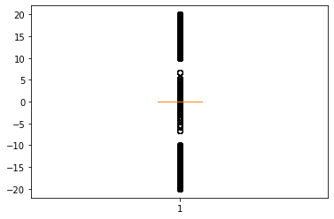

```
Post Length
```

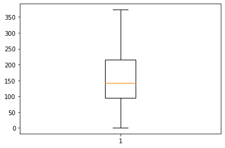

```
Hashtag count
```

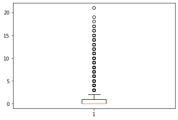

```
Content URL count
```

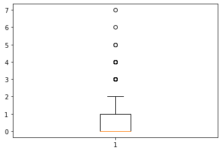

```
Tweet count
```

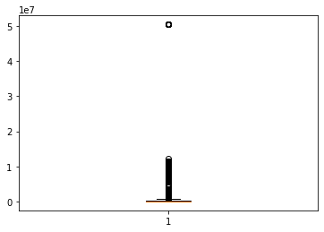

```
Followers count
```

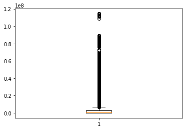

```
Listed Count
```

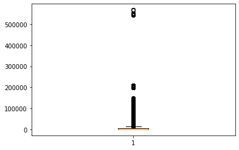

```
Mentions Count
```

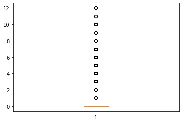

```
Post author verified
```

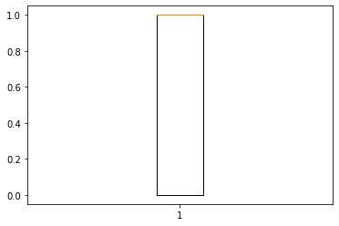

```
Likes
```

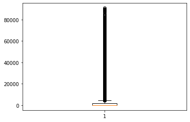

```
Shares
```

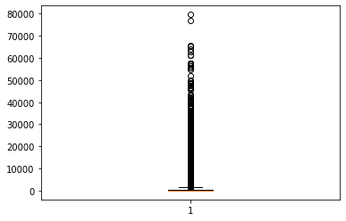

```
Comments
```

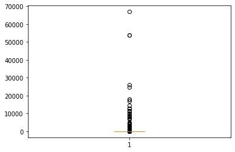

```
Impact
```

[1 more figures not shown]

```python
for i in numerical:
    print(i)
    plt.boxplot(df[i])
    plt.show()
```

# Spliting the data

```python
X = df2.drop('Impact',axis=1)
y = df2['Impact']
X_train, X_test, y_train, y_test = train_test_split(X, y, test_size=0.30, random_state=8)
print(X_train.shape, X_test.shape, y_train.shape, y_test.shape)
```

```
(35000, 14) (15000, 14) (35000,) (15000,)
```

# Building Models

## 1.Stats model

```python
import statsmodels
import statsmodels.api as sm
X = df2.drop('Impact',axis=1)
y = df2['Impact']
Xc = sm.add_constant(X)
model = sm.OLS(y,X).fit()

# print model summary
print(model.summary())
```

```
                                 OLS Regression Results
=======================================================================================
Dep. Variable:                 Impact   R-squared (uncentered):                   1.000
Model:                            OLS   Adj. R-squared (uncentered):              1.000
Method:                 Least Squares   F-statistic:                          8.885e+11
Date:                Fri, 06 Aug 2021   Prob (F-statistic):                        0.00
Time:                        00:20:12   Log-Likelihood:                     -1.6831e+05
No. Observations:               50000   AIC:                                  3.367e+05
Df Residuals:                   49986   BIC:                                  3.368e+05
Df Model:                          14
Covariance Type:            nonrobust
========================================================================================
                           coef    std err          t      P>|t|      [0.025      0.975]
----------------------------------------------------------------------------------------
Sentiment score          0.0018      0.003      0.600      0.549      -0.004       0.008
Post Length              0.0003      0.000      0.877      0.381      -0.000       0.001
Hashtag count            0.0192      0.024      0.802      0.423      -0.028       0.066
Content URL count       -0.1585      0.066     -2.412      0.016      -0.287      -0.030
Tweet count          -1.168e-10   1.97e-08     -0.006      0.995   -3.87e-08    3.85e-08
Followers count      -7.957e-09   3.56e-09     -2.236      0.025   -1.49e-08   -9.82e-10
Listed Count          5.313e-06   1.53e-06      3.473      0.001    2.31e-06    8.31e-06
Mentions Count           0.0129      0.062      0.208      0.835      -0.109       0.135
Post author verified    -0.2329      0.070     -3.315      0.001      -0.371      -0.095
Likes                   10.0000   4.81e-06   2.08e+06      0.000      10.000      10.000
Shares                  10.0000    1.2e-05   8.31e+05      0.000      10.000      10.000
Comments                10.0000   5.78e-05   1.73e+05      0.000      10.000      10.000
TEXT                    -0.0024      0.058     -0.041      0.967      -0.115       0.111
VIDEO                    0.0254      0.151      0.168      0.866      -0.270       0.321
==============================================================================
Omnibus:                   203367.321   Durbin-Watson:                   2.001
Prob(Omnibus):                  0.000   Jarque-Bera (JB):     436321993087.070
Skew:                        -107.922   Prob(JB):                         0.00
Kurtosis:                   14473.244   Cond. No.                     6.46e+07
==============================================================================

Warnings:
[1] Standard Errors assume that the covariance matrix of the errors is correctly specified.
[2] The condition number is large, 6.46e+07. This might indicate that there are
strong multicollinearity or other numerical problems.
```

- Content URL count,Followers count,Listed Count, Post author verified,Likes,Shares and Comments these are 7 features which are statistical significant
- R squared got 100% its overfit model

# 2.Linear Regression

```python
from sklearn.preprocessing import StandardScaler, PowerTransformer
pt = PowerTransformer()
X_train_power=pd.DataFrame(pt.fit_transform(X_train),columns=X_train.columns)
X_test_power=pd.DataFrame(pt.transform(X_test),columns=X_test.columns)
```

- Performed PowerTransformer for scaling and transforming the data

```python
from sklearn.model_selection import cross_val_score,KFold
```

```python
from sklearn import metrics
lin = LinearRegression()
lin.fit(X_train_power,y_train)
# K-fold-cross validation
kf=KFold(n_splits=5,shuffle=True,random_state=1)
# evaluate model
mse = cross_val_score(lin, X_train_power, y_train, scoring='neg_mean_squared_error',cv=kf)
rmse=np.sqrt(np.abs(mse))
# report performance
print(lin.score(X_train_power,y_train))
print('RMSE: %.3f (%.3f)' % (np.mean(rmse), np.std(rmse,ddof=1)))
prediction=lin.predict(X_test_power)
r2_li = metrics.r2_score(y_test, prediction)
print(r2_li)
```

```
0.32836010681204253
RMSE: 84283.501 (1413.096)
0.3265634811447242
```

- Linear Regression accuracy got 32% which means its underfit model
- RMSE also got very high 84283.501 (1413.096)

# 3.Decision Tree Regressor

```python
dt = DecisionTreeRegressor(random_state = 8) #without tuned
dt.fit(X_train_power,y_train)
print("Training Accuracy")
print(dt.score(X_train_power,y_train))
print("Testing Accuracy")
print(dt.score(X_test_power,y_test))
prediction=dt.predict(X_test_power)
```

```
Training Accuracy
1.0
Testing Accuracy
0.9976011726571621
```

```python
print('MAE:', metrics.mean_absolute_error(y_test,prediction))
print('MSE:', metrics.mean_squared_error(y_test, prediction))
print('RMSE:', np.sqrt(metrics.mean_squared_error(y_test, prediction)))
```

```
MAE: 792.704
MSE: 25823104.0
RMSE: 5081.643828526356
```

- We got 100% training accuracy with the decision tree regressor which means its overfit model

### GridSearch for DecisionTree:

```python
from sklearn.model_selection import GridSearchCV
```

```python
#Grid Search, find best parameters and use those tuned parameters to build the complete decision tree
parameters={"splitter":["best","random"],
            "max_depth" : [1,3,5,7,9,11,12],
            }
dt = DecisionTreeRegressor(random_state = 8)
tree_grid = GridSearchCV(estimator = dt,
                         param_grid = parameters,
                         cv = 5,scoring='neg_mean_squared_error')
# fit the model on X_train and y_train using fit()
tree_grid.fit(X_train_power, y_train)
```

```
GridSearchCV(cv=5, error_score=nan,
             estimator=DecisionTreeRegressor(ccp_alpha=0.0, criterion='mse',
                                             max_depth=None, max_features=None,
                                             max_leaf_nodes=None,
                                             min_impurity_decrease=0.0,
                                             min_impurity_split=None,
                                             min_samples_leaf=1,
                                             min_samples_split=2,
                                             min_weight_fraction_leaf=0.0,
                                             presort='deprecated',
                                             random_state=8, splitter='best'),
             iid='deprecated', n_jobs=None,
             param_grid={'max_depth': [1, 3, 5, 7, 9, 11, 12],
                         'splitter': ['best', 'random']},
             pre_dispatch='2*n_jobs', refit=True, return_train_score=False,
             scoring='neg_mean_squared_error', verbose=0)
```

```python
# best hyperparameters
tree_grid.best_params_
```

```
{'max_depth': 9, 'splitter': 'best'}
```

# Training Decision Tree With Best Hyperparameters

```python
tuned_model= DecisionTreeRegressor(criterion='mse',max_depth=9,max_features='auto',splitter='best')
# fitting model
tuned_model.fit(X_train_power,y_train)
tuned_model.fit(X_train_power,y_train)
print("Training Accuracy")
print(tuned_model.score(X_train_power,y_train))
print("Testing Accuracy")
print(tuned_model.score(X_test_power,y_test))
prediction=tuned_model.predict(X_test_power)
r2_dt = metrics.r2_score(y_test, prediction)
```

```
Training Accuracy
0.9990375749429748
Testing Accuracy
0.9967743237415799
```

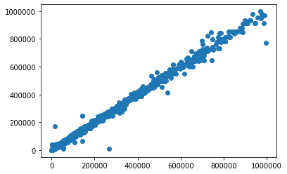

```python
# prediction
tuned_pred=tuned_model.predict(X_test_power)
plt.scatter(y_test,tuned_pred)
```

- Most of the data points are on best fit line which clearly shows its a over fit model

```python
# With hyperparameter tuned
print('MAE:', metrics.mean_absolute_error(y_test,tuned_pred))
print('MSE:', metrics.mean_squared_error(y_test, tuned_pred))
print('RMSE:', np.sqrt(metrics.mean_squared_error(y_test, tuned_pred)))
```

```
MAE: 1788.6653255278832
MSE: 34724038.70174533
RMSE: 5892.710641270733
```

# 4. Random Forest Regressor

```python
rf = RandomForestRegressor(random_state = 8)
rf.fit(X_train_power,y_train)
print("Training Accuracy")
print(rf.score(X_train_power,y_train))
print("Testing Accuracy")
print(rf.score(X_test_power,y_test))
prediction=rf.predict(X_test_power)
```

```
Training Accuracy
0.9997802565826674
Testing Accuracy
0.9988515480517306
```

### GridSearch for RandomForest:

```python
#Grid Search, find best parameters and use those tuned parameters to build the complete random forest
param_grid = [
{'n_estimators': [5,10,15], 'max_features': [5, 10],
 'max_depth': [5,10,]}
]

grid_search_forest = GridSearchCV(rf, param_grid, cv=5, scoring='neg_mean_squared_error')
grid_search_forest.fit(X_train_power, y_train)
```

```
GridSearchCV(cv=5, error_score=nan,
             estimator=RandomForestRegressor(bootstrap=True, ccp_alpha=0.0,
                                             criterion='mse', max_depth=None,
                                             max_features='auto',
                                             max_leaf_nodes=None,
                                             max_samples=None,
                                             min_impurity_decrease=0.0,
                                             min_impurity_split=None,
                                             min_samples_leaf=1,
                                             min_samples_split=2,
                                             min_weight_fraction_leaf=0.0,
                                             n_estimators=100, n_jobs=None,
                                             oob_score=False, random_state=8,
                                             verbose=0, warm_start=False),
             iid='deprecated', n_jobs=None,
             param_grid=[{'max_depth': [5, 10], 'max_features': [5, 10],
                          'n_estimators': [5, 10, 15]}],
             pre_dispatch='2*n_jobs', refit=True, return_train_score=False,
             scoring='neg_mean_squared_error', verbose=0)
```

```python
grid_search_forest.best_params_
```

```
{'max_depth': 10, 'max_features': 10, 'n_estimators': 15}
```

# Training Random Forest With Best Hyperparameters

```python
rf = RandomForestRegressor(n_estimators= 15,random_state = 8,max_depth= 10,max_features= 10)
rf.fit(X_train_power,y_train)
print("Training Accuracy")
print(rf.score(X_train_power,y_train))
print("Testing Accuracy")
print(rf.score(X_test_power,y_test))
prediction=rf.predict(X_test_power)
r2_rm = metrics.r2_score(y_test, prediction)
```

```
Training Accuracy
0.9994560101649124
Testing Accuracy
0.9981627620059172
```

```python
print('MAE:', metrics.mean_absolute_error(y_test,prediction))
print('MSE:', metrics.mean_squared_error(y_test, prediction))
print('RMSE:', np.sqrt(metrics.mean_squared_error(y_test, prediction)))
```

```
MAE: 939.0761380021538
MSE: 19777658.419476252
RMSE: 4447.20793526413
```

- After performing RandomForest there is not much improvement as compare to DecisionTree
- We can say model performing very well on training and testing accuracy
- RMSE has been improved

# Comparison models

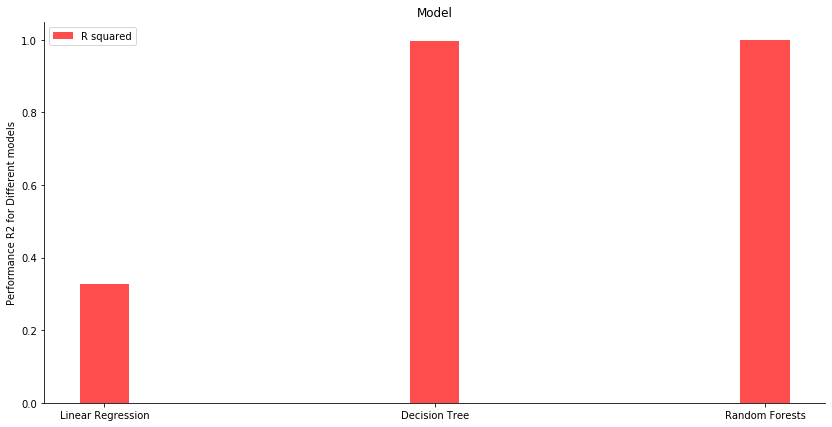

```python
plt.figure(figsize=(14, 7))
ax = plt.subplot(111)
models = ['Linear Regression','Decision Tree', 'Random Forests']
values = [r2_li ,r2_dt, r2_rm]
model = np.arange(len(models))
plt.bar(model, values, align='center', width = 0.15, alpha=0.7, color = 'red', label= 'R squared')
plt.ylabel('Performance R2 for Different models')
plt.title('Model')
plt.xticks(model, models)
# removing the axis on the top and right of the plot window
ax.spines['right'].set_visible(False)
ax.spines['top'].set_visible(False)
ax.legend()

plt.show()
```